# Section 4: Cross-Validation

Pablo Arés Gastesi

2026-06-11

# 1 Introduction

A central problem in machine learning is model evaluation: how well does a fitted model predict on new data it has never seen? Using the training error for this is misleading — a sufficiently complex model can fit the training data almost perfectly while generalising very poorly.

But, how can we know the error we are going to have with our model on new, unseen data, if the data are new? **Cross-validation (CV)** is a family of resampling techniques that estimate test error using only the available data, by repeatedly holding out a portion of it as a proxy for new observations. That is, we will take one part of the data to train the model, and another part to test its performance, which is possible as we have the values of the response.

There are several approaches to cross validation. In this section we will study three of them, all illustrated with the `Auto` dataset of the `ISLR2` package. Cross validation is more natural to use in supervised learning, which is what we do here.

Throughout, the task is to choose the degree of a polynomial regression of `mpg` on `horsepower`.

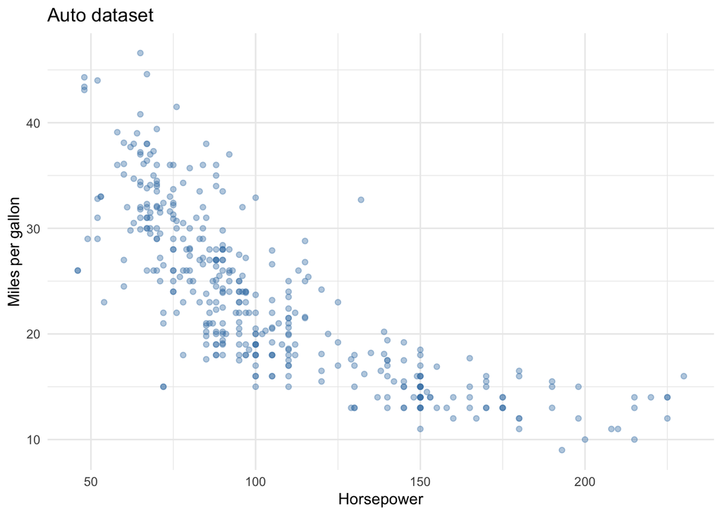

```r
data(Auto)
ggplot(Auto, aes(x = horsepower, y = mpg)) +
  geom_point(alpha = 0.4, colour = "steelblue") +
  labs(title = "Auto dataset", x = "Horsepower", y = "Miles per gallon") +
  theme_minimal()
```

# 2 Validation Set Approach

This technique consists of randomly splitting the data in two disjoint sets, know as the training set and the test set. The first one is used to fit the model, while the second set is used for evaluating that model. If the reponse variable in the data is $y_i$, and the prediction is $\widehat{y_i}$ we could use, for example, the test Mean Squared Error in the case of a linear model, for our evaluation:

$$\text{MSE} = \frac{1}{n_\text{test}} \sum_{i \in \text{test}} (y_i - \hat{y}_i)^2$$

How big should be the training set? There are no fixed rules, but a subset with 70% or 80% of the data is frequently used.

To check this approach with R we follow the ISLR book, and thus we split the data into two equal size sets, one used for training and the other for testing.

```r
set.seed(1)
train <- sample(392, 196)   # 50 / 50 split

# Helper: compute test MSE for a model fitted on `train`
mse_function <- function(the_train, the_model) {
  mean((Auto$mpg[-the_train] - predict(the_model, Auto)[-the_train])^2)
}

modelo_1 <- lm(mpg ~ horsepower,           data = Auto, subset = train)
modelo_2 <- lm(mpg ~ poly(horsepower, 2),  data = Auto, subset = train)
modelo_3 <- lm(mpg ~ poly(horsepower, 3),  data = Auto, subset = train)

cat(" MSE for linear model.  : ", mse_function(train, modelo_1), "\n",
    "MSE for quadratic model: ", mse_function(train, modelo_2), "\n",
    "MSE for cubic model.   : ", mse_function(train, modelo_3))
```

```
##  MSE for linear model.  :  23.26601
##  MSE for quadratic model:  18.71646
##  MSE for cubic model.   :  18.79401
```

The best model, according to the rule of smaller MSE, is the quadratic one. We can see the fitting graphically in the following figure.

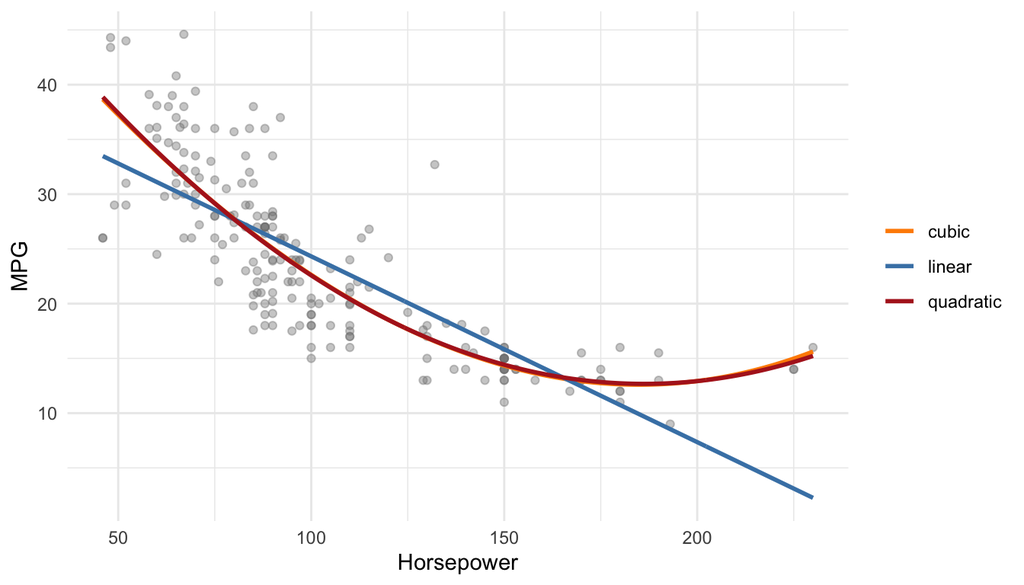

Figure 2.1: Polynomial fittings on training set

```r
new_data <- data.frame(horsepower = seq(min(Auto$horsepower),
                                        max(Auto$horsepower),
                                        length.out = 300))
new_data$linear    <- predict(modelo_1, newdata = new_data)
new_data$quadratic <- predict(modelo_2, newdata = new_data)
new_data$cubic     <- predict(modelo_3, newdata = new_data)

new_long <- new_data %>%
  pivot_longer(-horsepower, names_to = "Model", values_to = "mpg")

ggplot(Auto[train, ], aes(x = horsepower, y = mpg)) +
  geom_point(alpha = 0.4, colour = "grey50") +
  geom_line(data = new_long, aes(colour = Model), linewidth = 1) +
  scale_colour_manual(values = c(linear = "steelblue",
                                 quadratic = "firebrick",
                                 cubic = "darkorange")) +
  labs(x = "Horsepower", y = "MPG", colour = NULL) +
  theme_minimal()
```

One sees that the quadratic and cubic are almost identical, which can be guessed from the MSE values.

A useful tool is to visualize the error, or rather, the histograms of the errors for the different models.

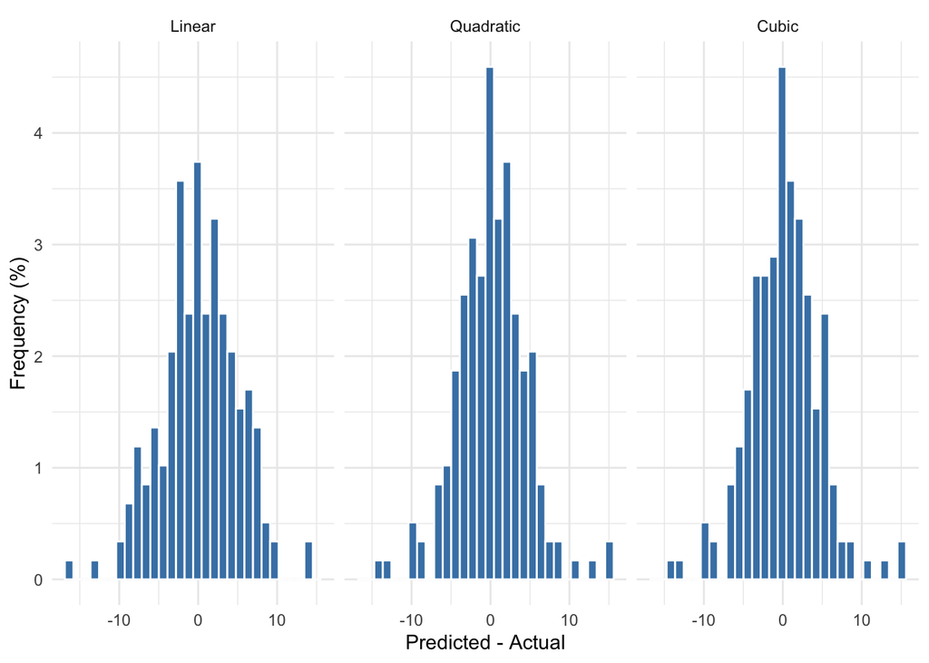

Figure 2.2: Prediction errors on test set

```r
residuals_df <- data.frame(
  error = c(predict(modelo_1, Auto)[-train] - Auto$mpg[-train],
            predict(modelo_2, Auto)[-train] - Auto$mpg[-train],
            predict(modelo_3, Auto)[-train] - Auto$mpg[-train]),
  model = rep(factor(c("Linear", "Quadratic", "Cubic"),
                     levels = c("Linear", "Quadratic", "Cubic")),
              each = length(Auto$mpg[-train]))
)

ggplot(residuals_df, aes(x = error)) +
  geom_histogram(aes(y = after_stat(count / sum(count) * 100)),
                 fill = "steelblue", colour = "white", bins = 30) +
  facet_wrap(~ model) +
  labs(x = "Predicted - Actual", y = "Frequency (%)") +
  theme_minimal()
```

The errors in the quadratic and cubic polynomials are more concentrated around 0, showing that these two models are better than the linear regression.

What happens if we increase the degree of the polynomial? Will we get better results?

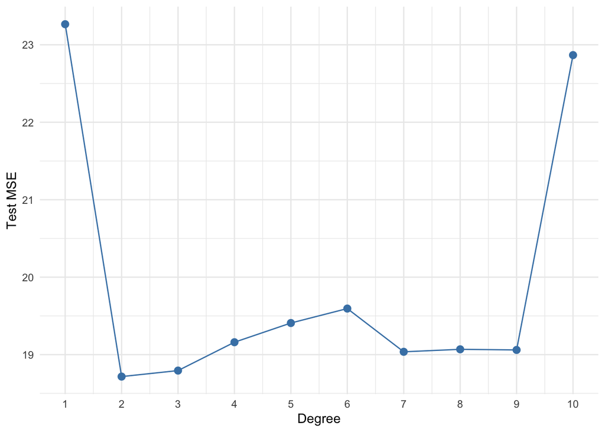

Figure 2.3: Test MSE by polynomial degree

```r
mse_vector <- vector(mode = "double", length = 10)
for (i in 1:10)
{
  modelo <- lm(mpg ~ poly(horsepower, i), data = Auto, subset = train)
  mse_vector[i] <- mse_function(train, modelo)
}

mse_df <- data.frame(degree = 1:10, MSE = mse_vector)

ggplot(mse_df, aes(x = degree, y = MSE)) +
  geom_line(colour = "steelblue") +
  geom_point(colour = "steelblue", size = 2.5) +
  scale_x_continuous(breaks = 1:10) +
  labs(x = "Degree", y = "Test MSE") +
  theme_minimal()
```

## 2.1 Sensitivity to the split

A key weakness of the validation set approach is that the estimated test MSE depends heavily on which observations end up in the training set. To see this, we repeat the above procedure for 10 different (random) splits.

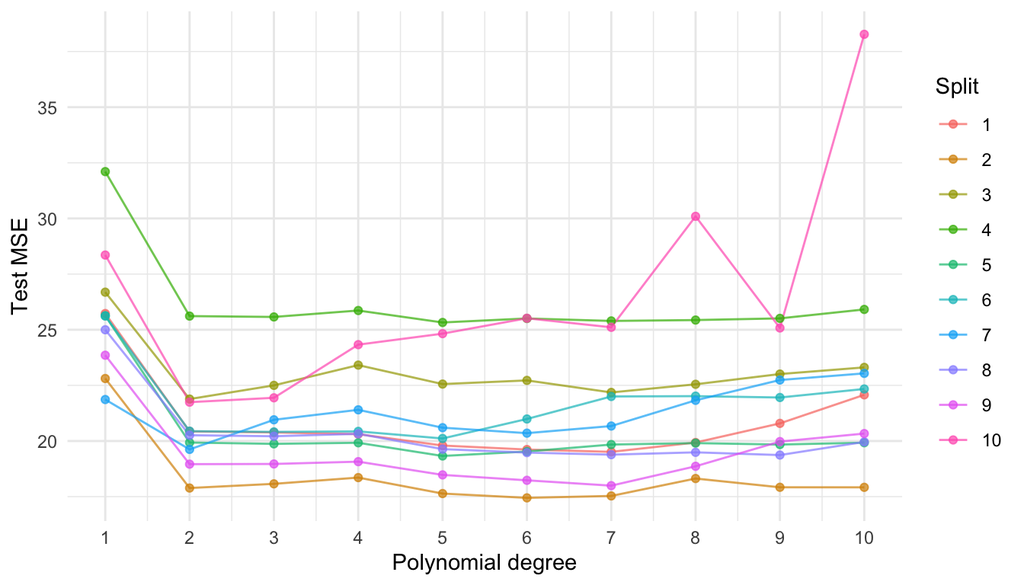

Figure 2.4: Validation set MSE — 10 different splits

```r
set.seed(2)
results_splits <- lapply(1:10, function(rep) {
  tr <- sample(392, 196)
  mse_vec <- sapply(1:10, function(deg) {
    mod <- lm(mpg ~ poly(horsepower, deg), data = Auto, subset = tr)
    mse_function(tr, mod)
  })
  data.frame(degree = 1:10, MSE = mse_vec, rep = rep)
})

splits_df <- bind_rows(results_splits)

ggplot(splits_df, aes(x = degree, y = MSE,
                      colour = factor(rep), group = factor(rep))) +
  geom_line(alpha = 0.7) +
  geom_point(size = 1.5, alpha = 0.7) +
  scale_x_continuous(breaks = 1:10) +
  labs(x = "Polynomial degree", y = "Test MSE", colour = "Split") +
  theme_minimal()
```

> The curves have the same broad shape (degree 2 is good, higher degrees don’t help much), but the exact values vary considerably. This variability is a major drawback of the validation set approach.

## 2.2 Effect of training set size

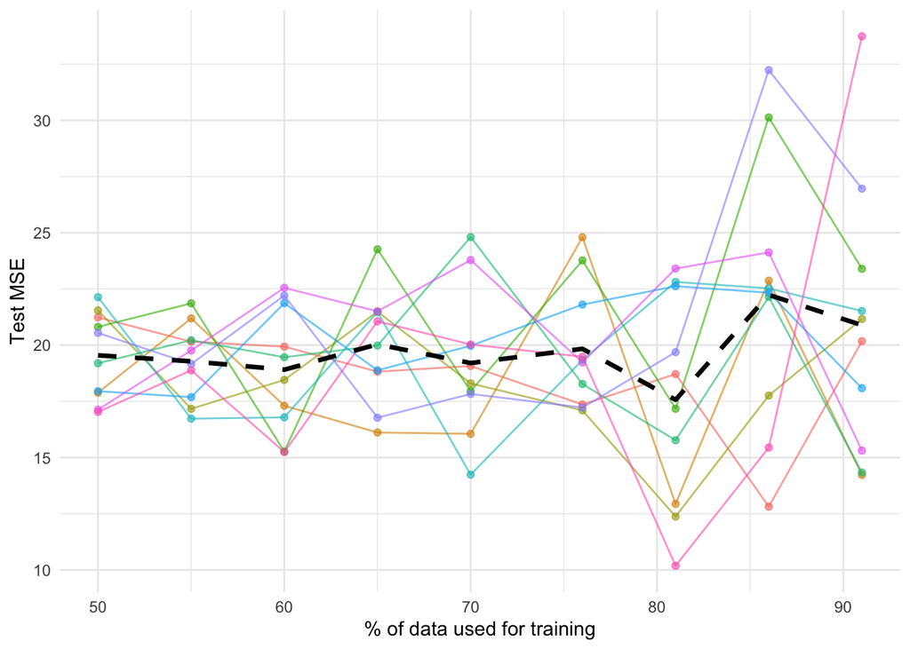

Figure 2.5: Test MSE vs training set size (quadratic model), dashed line is the mean

```r
sizes  <- seq(196, 356, by = 20)
n_reps <- 10

size_df <- expand.grid(size = sizes, rep = 1:n_reps) %>%
  rowwise() %>%
  mutate(
    pct_train = round(size / 392 * 100),
    MSE = {
      tr  <- sample(392, size)
      mod <- lm(mpg ~ poly(horsepower, 2), data = Auto, subset = tr)
      mse_function(tr, mod)
    }
  ) %>%
  ungroup()

ggplot(size_df, aes(x = pct_train, y = MSE,
                    colour = factor(rep), group = factor(rep))) +
  geom_line(alpha = 0.6) +
  geom_point(size = 1.5, alpha = 0.6) +
  stat_summary(aes(group = 1), fun = mean, geom = "line",
               colour = "black", linewidth = 1.2, linetype = "dashed") +
  scale_colour_discrete(guide = "none") +
  labs(x = "% of data used for training", y = "Test MSE") +
  theme_minimal()
```

> Note: without a fixed seed, there is another source of variability here — the random choice of which observations go into training. The lesson is to be careful: many choices enter the picture, and the validation set approach gives just one noisy estimate.

# 3 Leave-One-Out Cross-Validation (LOOCV)

Instead of one big split, we hold out one observation at a time:

1. Fit the model on all $n - 1$ remaining observations.
2. Compute the error: $\text{MSE}_i = (y_i - \hat y_i)^2$.
3. Repeat for every $i = 1, \ldots, n$.

The LOOCV estimate is the average of the $n$ errors:

$$CV_n = \frac{1}{n} \sum_{i=1}^{n} \text{MSE}_i$$

The estimate has low bias but can have high variance (all $n$ models are very similar, so their errors are correlated).

We compute the average MSE for the linear model (same dataset, `Auto`; same fitting, `mpg` on `horsepower`)

```r
n     <- nrow(Auto)
error <- numeric(n)

for (i in 1:n) {
  mod      <- lm(mpg ~ horsepower, data = Auto[-i, ])
  error[i] <- (Auto$mpg[i] - predict(mod, Auto[i, ]))^2
}
cv_loocv <- mean(error)
cv_loocv
```

```
## [1] 24.23151
```

For linear models, `cv.glm()` from `boot` computes LOOCV efficiently (no loop needed):

```r
glm_fit  <- glm(mpg ~ horsepower, data = Auto)
cv_err   <- cv.glm(Auto, glm_fit)
cv_err$delta[1]   # should match manual result above
```

```
## [1] 24.23151
```

`delta[1]` is the raw CV estimate; `delta[2]` is a bias-corrected version (usually very similar).

Below we plot the LOOCV average MSE for polynomials models ranging from degree 1 (linear) up to degree 10.

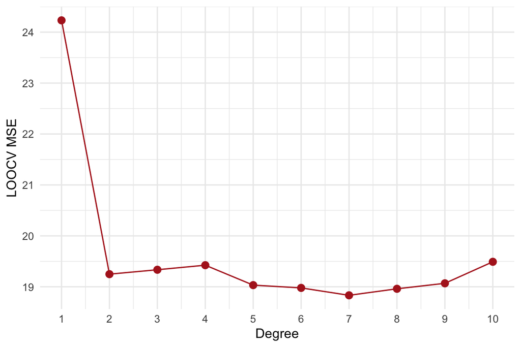

Figure 3.1: LOOCV error by polynomial degree

```r
cv_loocv_vec <- sapply(1:10, function(deg) {
  fit <- glm(mpg ~ poly(horsepower, deg), data = Auto)
  cv.glm(Auto, fit)$delta[1]
})

loocv_df <- data.frame(degree = 1:10, CV_MSE = cv_loocv_vec)

ggplot(loocv_df, aes(x = degree, y = CV_MSE)) +
  geom_line(colour = "firebrick") +
  geom_point(colour = "firebrick", size = 2.5) +
  scale_x_continuous(breaks = 1:10) +
  labs(x = "Degree", y = "LOOCV MSE") +
  theme_minimal()
```

> Again, degree 2 gives the clearest improvement; beyond that the error barely moves. We now have a *much more stable* estimate than the single validation set gave us.

# 4 k-Fold Cross-Validation

Partition the data into $k$ roughly equal **folds**. For each fold $j$:

1. Train on the other $k - 1$ folds.
2. Compute the error on the $j$ set: $\text{MSE}_j$.

The CV estimate is the average of the $k$ errors:

$$CV_k = \frac{1}{k} \sum_{j=1}^{k} \text{MSE}_j$$

In practice $k = 5$ or $k = 10$ is standard — they produce good estimates at a fraction of the computational cost.

Observe that the Leave-One-Out Cross Validation is a $k$-Fold Cross Validation when $k = n$ (number of data points).

The figure below plots the CV errors of a 10-fold CV for polynomials of degree 1 to 10. And the table shows the actual values of those errors.

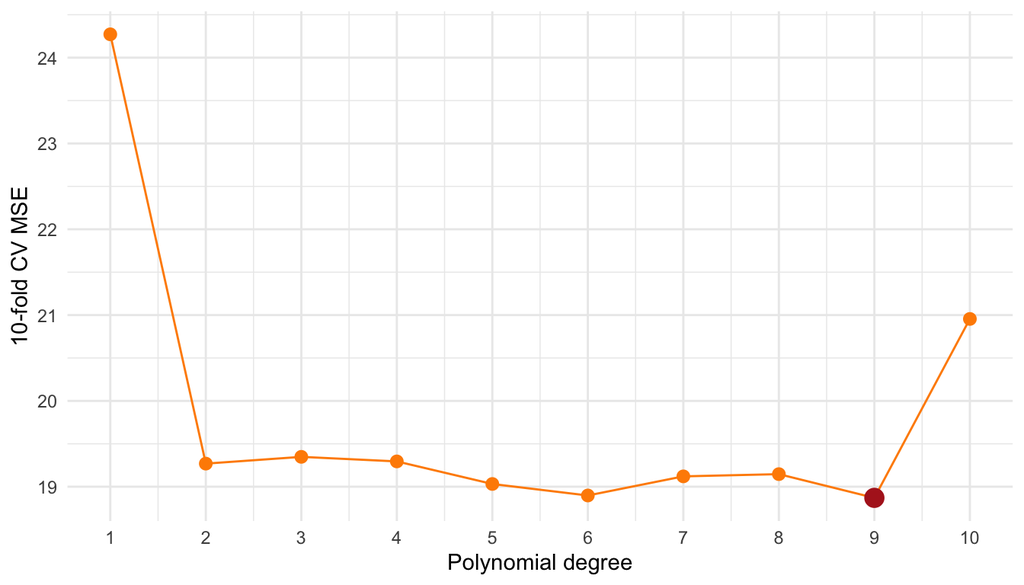

Figure 4.1: 10-fold CV error by polynomial degree

```r
set.seed(17)
cv_10fold <- sapply(1:10, function(deg) {
  fit <- glm(mpg ~ poly(horsepower, deg), data = Auto)
  cv.glm(Auto, fit, K = 10)$delta[1]
})

kfold_df <- data.frame(degree = 1:10, CV_MSE = cv_10fold)

ggplot(kfold_df, aes(x = degree, y = CV_MSE)) +
  geom_line(colour = "darkorange") +
  geom_point(colour = "darkorange", size = 2.5) +
  geom_point(data = kfold_df[which.min(kfold_df$CV_MSE), ],
             colour = "firebrick", size = 4) +
  scale_x_continuous(breaks = 1:10) +
  labs(x = "Polynomial degree", y = "10-fold CV MSE") +
  theme_minimal()
```

```r
cat("Best degree by 10-fold CV:", which.min(cv_10fold), "\n")
```

```
## Best degree by 10-fold CV: 9
```

```r
kfold_df
```

| degree | CV_MSE |
| --- | --- |
| 1 | 24.27207 |
| 2 | 19.26909 |
| 3 | 19.34805 |
| 4 | 19.29496 |
| 5 | 19.03198 |
| 6 | 18.89781 |
| 7 | 19.12061 |
| 8 | 19.14666 |
| 9 | 18.87013 |
| 10 | 20.95520 |

## 4.1 Comparing all three methods

| Method | Bias | Variance | Cost |
| --- | --- | --- | --- |
| Validation set | High | High | Low |
| LOOCV | Low | High | Very high ($n$ models) |
| 10-fold CV | Low–moderate | Low–moderate | Moderate (10 models) |

The figure below shows the CV error by method and degree of the polynomial model.

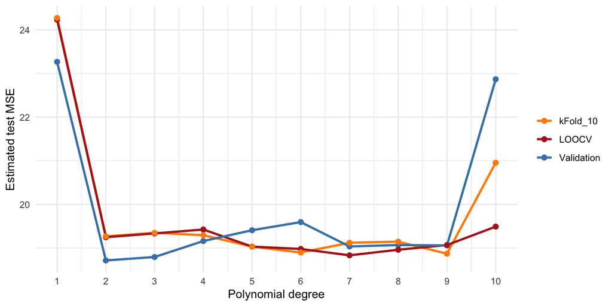

```r
cv_validation <- sapply(1:10, function(deg) {
  set.seed(1)
  tr  <- sample(392, 196)
  mod <- lm(mpg ~ poly(horsepower, deg), data = Auto, subset = tr)
  mse_function(tr, mod)
})

cv_loocv_10 <- sapply(1:10, function(deg) {
  fit <- glm(mpg ~ poly(horsepower, deg), data = Auto)
  cv.glm(Auto, fit)$delta[1]
})

compare_df <- data.frame(
  degree     = 1:10,
  Validation = cv_validation,
  LOOCV      = cv_loocv_10,
  kFold_10   = cv_10fold
) %>%
  pivot_longer(-degree, names_to = "Method", values_to = "CV_MSE")

ggplot(compare_df, aes(x = degree, y = CV_MSE,
                       colour = Method, group = Method)) +
  geom_line(linewidth = 1) +
  geom_point(size = 2) +
  scale_x_continuous(breaks = 1:10) +
  scale_colour_manual(values = c(Validation = "steelblue",
                                 LOOCV      = "firebrick",
                                 kFold_10   = "darkorange")) +
  labs(x = "Polynomial degree", y = "Estimated test MSE", colour = NULL) +
  theme_minimal()
```

> All three methods agree on the main conclusion (degree 2 is sufficient), but LOOCV and 10-fold CV are far more stable than the single validation set.